# Perfect Plots: Pie Plot

An old Chinese proverb says: one picture says more than one thousands words. One good plot can rescue entire presentation. One poor picture can drown down all good speech. After plenty of shame appointment and boring presentations I decided to improve my tools of visualisation.

```python
import pandas as pd

df1 = pd.read_csv('c:/11/freeFormResponses.csv', skiprows = 1)
```

```python
headers = ['Duration (in seconds)', 'Gender', 'Gender2','Age','Country','Education', 'Major_undergraduate','Recent_role', 'Recent_role2', 'Industry','Industry2' ,'Years_of_experience', 'compensation$USD']
df = pd.read_csv('c:/11/multipleChoiceResponses.csv', usecols=[0,1,2,3,4,5,6,7,8,9,10,11,12], header=None, names=headers, skiprows=2)
df.head(4)
```

|  | Duration (in seconds) | Gender | Gender2 | Age | Country | Education | Major_undergraduate | Recent_role | Recent_role2 | Industry | Industry2 | Years_of_experience | compensation$USD |
| --- | --- | --- | --- | --- | --- | --- | --- | --- | --- | --- | --- | --- | --- |
| 0 | 710 | Female | -1 | 45-49 | United States of America | Doctoral degree | Other | Consultant | -1 | Other | 0 | NaN | NaN |
| 1 | 434 | Male | -1 | 30-34 | Indonesia | Bachelor’s degree | Engineering (non-computer focused) | Other | 0 | Manufacturing/Fabrication | -1 | 5-10 | 10-20,000 |
| 2 | 718 | Female | -1 | 30-34 | United States of America | Master’s degree | Computer science (software engineering, etc.) | Data Scientist | -1 | I am a student | -1 | 0-1 | 0-10,000 |
| 3 | 621 | Male | -1 | 35-39 | United States of America | Master’s degree | Social sciences (anthropology, psychology, soc... | Not employed | -1 | NaN | -1 | NaN | NaN |

```python
df.drop(['Gender2','Recent_role2','Industry2'], axis=1, inplace=True)
```

### Correcting data

Every time when we want to do plot we will need to check and improve data. Especially check of unique occurrences and elimination of minority of rubbish and NaN cells (lack of data).

```python
df.isnull().sum()
```

```
Duration (in seconds)       0
Gender                      0
Age                         0
Country                     0
Education                 421
Major_undergraduate       912
Recent_role               959
Industry                 2174
Years_of_experience      2758
compensation$USD         3674
dtype: int64
```

```python
df.dtypes
```

```
Duration (in seconds)     int64
Gender                   object
Age                      object
Country                  object
Education                object
Major_undergraduate      object
Recent_role              object
Industry                 object
Years_of_experience      object
compensation$USD         object
dtype: object
```

Very important is reduction of the class or join some similar groups if it is not bad for the project.

```python
df['Gender']=df['Gender'].replace('Prefer to self-describe', 'Prefer not to say')
```

```python
df.Education.value_counts(dropna = False)
```

```
Master’s degree                                                      10855
Bachelor’s degree                                                     7083
Doctoral degree                                                       3357
Some college/university study without earning a bachelor’s degree      967
Professional degree                                                    599
NaN                                                                    421
I prefer not to answer                                                 345
No formal education past high school                                   232
Name: Education, dtype: int64
```

We can get assumption if somebody didn't answer he didn't want to give information: 'I prefer not to answer'.

```python
import numpy as np

df['Education']=df['Education'].replace(np.NaN, 'I prefer not to answer')
```

```python
df.Education.value_counts(dropna = False)
```

```
Master’s degree                                                      10855
Bachelor’s degree                                                     7083
Doctoral degree                                                       3357
Some college/university study without earning a bachelor’s degree      967
I prefer not to answer                                                 766
Professional degree                                                    599
No formal education past high school                                   232
Name: Education, dtype: int64
```

```python
df.Education.isnull().sum()
```

```
0
```

```python
df.Major_undergraduate.value_counts(dropna = False)
```

```
Computer science (software engineering, etc.)                    9430
Engineering (non-computer focused)                               3705
Mathematics or statistics                                        2950
A business discipline (accounting, economics, finance, etc.)     1791
Physics or astronomy                                             1110
Information technology, networking, or system administration     1029
NaN                                                               912
Medical or life sciences (biology, chemistry, medicine, etc.)     871
Other                                                             770
Social sciences (anthropology, psychology, sociology, etc.)       554
Humanities (history, literature, philosophy, etc.)                269
Environmental science or geology                                  253
I never declared a major                                          128
Fine arts or performing arts                                       87
Name: Major_undergraduate, dtype: int64
```

Rozumiem, że NaN i 'Other' jest wtedy, gdy ktoś nie chce zadeklarować swojej specjalizacji:'I never declared a major'

```python
df['Major_undergraduate']=df['Major_undergraduate'].replace(np.NaN, 'I never declared a major')
df['Major_undergraduate']=df['Major_undergraduate'].replace('Other', 'I never declared a major')
```

```python
import matplotlib as plt
df.Major_undergraduate.value_counts(dropna = False, normalize=True).plot(kind='barh')
```

[output not shown]

```python
df.Recent_role.value_counts(dropna=False)
```

```
Student                    5253
Data Scientist             4137
Software Engineer          3130
Data Analyst               1922
Other                      1322
Research Scientist         1189
NaN                         959
Not employed                842
Consultant                  785
Business Analyst            772
Data Engineer               737
Research Assistant          600
Manager                     590
Product/Project Manager     428
Chief Officer               360
Statistician                237
DBA/Database Engineer       145
Developer Advocate          117
Marketing Analyst           115
Salesperson                 102
Principal Investigator       97
Data Journalist              20
Name: Recent_role, dtype: int64
```

```python
df['Recent_role']=df['Recent_role'].replace(np.NaN, 'Other')
```

```python
Z1 = df.pivot_table(index=['Major_undergraduate'], columns = 'Gender', values='Age',aggfunc='count').sort_values('Male',ascending=False)
Z1
```

| Gender Major_undergraduate | Female | Male | Prefer not to say |
| --- | --- | --- | --- |
| Computer science (software engineering, etc.) | 1463 | 7837 | 130 |
| Engineering (non-computer focused) | 432 | 3223 | 50 |
| Mathematics or statistics | 660 | 2241 | 49 |
| I never declared a major | 297 | 1438 | 75 |
| A business discipline (accounting, economics, finance, etc.) | 334 | 1435 | 22 |
| Physics or astronomy | 119 | 968 | 23 |
| Information technology, networking, or system administration | 186 | 832 | 11 |
| Medical or life sciences (biology, chemistry, medicine, etc.) | 203 | 646 | 22 |
| Social sciences (anthropology, psychology, sociology, etc.) | 160 | 379 | 15 |
| Environmental science or geology | 57 | 190 | 6 |
| Humanities (history, literature, philosophy, etc.) | 74 | 185 | 10 |
| Fine arts or performing arts | 25 | 56 | 6 |

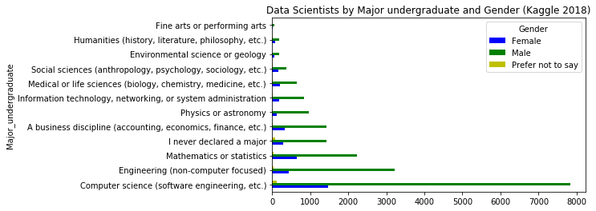

```python
Z1.plot(kind='barh', legend=True, title='Data Scientists by Major undergraduate and Gender (Kaggle 2018)', figsize=(7, 4), color=('b','g','y'))
```

```python
Z2 = df.pivot_table(index=['Country'], columns = 'Gender', values='Age',aggfunc='count', margins=True, margins_name='SUM').sort_values('Male',ascending=False).nlargest(20,'Male')
Z2
```

| Gender Country | Female | Male | Prefer not to say | SUM |
| --- | --- | --- | --- | --- |
| SUM | 4010.0 | 19430.0 | 419.0 | 23859 |
| India | 657.0 | 3719.0 | 41.0 | 4417 |
| United States of America | 1082.0 | 3530.0 | 104.0 | 4716 |
| China | 267.0 | 1337.0 | 40.0 | 1644 |
| Other | 165.0 | 849.0 | 22.0 | 1036 |
| Russia | 113.0 | 750.0 | 16.0 | 879 |
| Brazil | 65.0 | 666.0 | 5.0 | 736 |
| Germany | 103.0 | 621.0 | 10.0 | 734 |
| Japan | 34.0 | 557.0 | 6.0 | 597 |
| United Kingdom of Great Britain and Northern Ireland | 131.0 | 554.0 | 17.0 | 702 |
| France | 104.0 | 494.0 | 6.0 | 604 |
| Canada | 123.0 | 475.0 | 6.0 | 604 |
| Spain | 75.0 | 406.0 | 4.0 | 485 |
| Italy | 47.0 | 303.0 | 5.0 | 355 |
| Australia | 51.0 | 272.0 | 7.0 | 330 |
| Turkey | 56.0 | 267.0 | 4.0 | 327 |
| I do not wish to disclose my location | 83.0 | 250.0 | 61.0 | 394 |
| Poland | 54.0 | 243.0 | 4.0 | 301 |
| Netherlands | 41.0 | 225.0 | 4.0 | 270 |
| Ukraine | 31.0 | 218.0 | 3.0 | 252 |

### Poland in data

Because I am from Poland, most interesting data for me is information from my country. I separate data about Poland from original data.

```python
PL= df[df.Country=='Poland']
```

```python
Z3 = PL.pivot_table(index=['Major_undergraduate'], columns = 'Gender', values='Age',aggfunc='count', margins=True, margins_name='SUM').sort_values('Male',ascending=False)
Z3
```

| Gender Major_undergraduate | Female | Male | Prefer not to say | SUM |
| --- | --- | --- | --- | --- |
| SUM | 54.0 | 243.0 | 4.0 | 301 |
| Computer science (software engineering, etc.) | 15.0 | 96.0 | 1.0 | 112 |
| Mathematics or statistics | 12.0 | 39.0 | 1.0 | 52 |
| A business discipline (accounting, economics, finance, etc.) | 9.0 | 24.0 | 1.0 | 34 |
| Physics or astronomy | 4.0 | 20.0 | NaN | 24 |
| Engineering (non-computer focused) | 3.0 | 18.0 | 1.0 | 22 |
| I never declared a major | 2.0 | 15.0 | NaN | 17 |
| Information technology, networking, or system administration | 3.0 | 11.0 | NaN | 14 |
| Medical or life sciences (biology, chemistry, medicine, etc.) | NaN | 7.0 | NaN | 7 |
| Social sciences (anthropology, psychology, sociology, etc.) | 5.0 | 7.0 | NaN | 12 |
| Humanities (history, literature, philosophy, etc.) | NaN | 4.0 | NaN | 4 |
| Environmental science or geology | 1.0 | 2.0 | NaN | 3 |

```python
Z3 = PL.pivot_table(index=['Recent_role'], columns = 'Gender', values='Age',aggfunc='count', margins=True, margins_name='SUM').sort_values('Male',ascending=False)
Z3
```

| Gender Recent_role | Female | Male | Prefer not to say | SUM |
| --- | --- | --- | --- | --- |
| SUM | 54.0 | 243.0 | 4.0 | 301 |
| Data Scientist | 15.0 | 58.0 | NaN | 73 |
| Software Engineer | 4.0 | 46.0 | NaN | 50 |
| Student | 5.0 | 28.0 | NaN | 33 |
| Other | 5.0 | 21.0 | NaN | 26 |
| Data Analyst | 9.0 | 19.0 | 1.0 | 29 |
| Research Scientist | 2.0 | 15.0 | NaN | 17 |
| Consultant | 1.0 | 10.0 | NaN | 11 |
| Business Analyst | 2.0 | 9.0 | 1.0 | 12 |
| Manager | 1.0 | 6.0 | NaN | 7 |
| Research Assistant | 2.0 | 6.0 | NaN | 8 |
| Data Engineer | 2.0 | 5.0 | 1.0 | 8 |
| Not employed | 3.0 | 5.0 | 1.0 | 9 |
| Chief Officer | 1.0 | 4.0 | NaN | 5 |
| Product/Project Manager | 1.0 | 3.0 | NaN | 4 |
| DBA/Database Engineer | NaN | 3.0 | NaN | 3 |
| Statistician | NaN | 2.0 | NaN | 2 |
| Data Journalist | NaN | 1.0 | NaN | 1 |
| Principal Investigator | NaN | 1.0 | NaN | 1 |
| Salesperson | 1.0 | 1.0 | NaN | 2 |

### Let's do standard, quick Pie Plot

We can see banal, predictable visualization.

```
array([<matplotlib.axes._subplots.AxesSubplot object at 0x0000028B1DC64C50>],
      dtype=object)
```

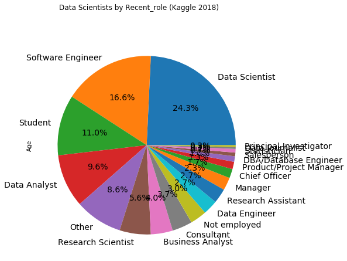

```python
Z4 = PL.pivot_table(index=['Recent_role'], values='Age',aggfunc='count').sort_values('Age', ascending=False)

Z4.plot(kind='pie', subplots=True, legend=False, title="Data Scientists by Recent_role (Kaggle 2018)",figsize=(15,7), autopct='%1.1f%%',fontsize=14)
```

```python
Z5 = PL.pivot_table(index=['Major_undergraduate'], values='Age',aggfunc='count').sort_values('Age', ascending=False)
Z5.head(10)
```

| Major_undergraduate | Age |
| --- | --- |
| Computer science (software engineering, etc.) | 112 |
| Mathematics or statistics | 52 |
| A business discipline (accounting, economics, finance, etc.) | 34 |
| Physics or astronomy | 24 |
| Engineering (non-computer focused) | 22 |
| I never declared a major | 17 |
| Information technology, networking, or system administration | 14 |
| Social sciences (anthropology, psychology, sociology, etc.) | 12 |
| Medical or life sciences (biology, chemistry, medicine, etc.) | 7 |
| Humanities (history, literature, philosophy, etc.) | 4 |

### Better Pie Plot with interesting colors

At the beginning we can change colors and give better descriptions.

GSuite Text and Background Palette: https://yagisanatode.com/2019/08/06/google-apps-script-hexadecimal-color-codes-for-google-docs-sheets-and-slides-standart-palette/

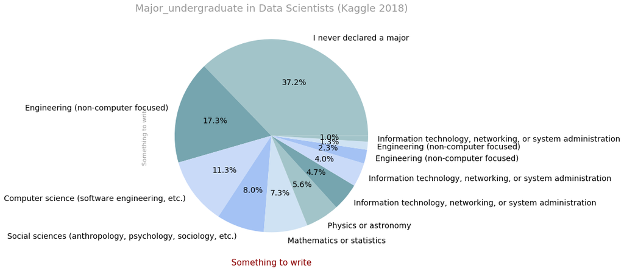

```python
import matplotlib.pyplot as plt
## Wielkość wykresu
plt.figure(figsize=(16,8))


## informacja że jest to wykres złożony
ax1 = plt.subplot(aspect='equal')



## ustalenie koloru
colors = ['#a2c4c9','#76a5af','#c9daf8','#a4c2f4', '#cfe2f3']

## równanie podstawowe
Z5.plot(kind='pie',colors =colors , y = 'Age', ax=ax1, autopct='%1.1f%%', startangle=0, shadow=False, labels=df['Major_undergraduate'], legend = False, fontsize=14)

# opisy, nazwy itp
ax1.set_xlabel('Something to write',  fontsize=15, color='darkred', alpha=1)
ax1.set_ylabel('Something to write', fontsize=11,  color='grey', alpha=0.8)
ax1.set_title('Major_undergraduate in Data Scientists (Kaggle 2018)',  fontsize=18, color='grey', alpha=0.8)
ax1.set_facecolor('#d8dcd6')
```

### The best Pie Plot

I came across this publication and decided to do Pie Plot by this way. https://medium.com/@kvnamipara/a-better-visualisation-of-pie-charts-by-matplotlib-935b7667d77f

To prepare perfect pie plot first I will need to pull vectors of data from the pivot table.

```python
PPL=Z5.reset_index()
PPL.head(5)
```

|  | Major_undergraduate | Age |
| --- | --- | --- |
| 0 | Computer science (software engineering, etc.) | 112 |
| 1 | Mathematics or statistics | 52 |
| 2 | A business discipline (accounting, economics, ... | 34 |
| 3 | Physics or astronomy | 24 |
| 4 | Engineering (non-computer focused) | 22 |

### To pull vectors of data from the pivot table.

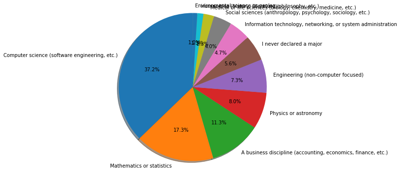

```python
PPL.reset_index()
labels = PPL['Major_undergraduate'].to_list()
sizes = PPL['Age'].to_list()

fig1, ax1 = plt.subplots(figsize=(10,5))


ax1.pie(sizes, labels=labels, autopct='%1.1f%%', shadow=True, startangle=90)

ax1.axis('equal')
plt.tight_layout()
plt.show()
```

### Colors changing

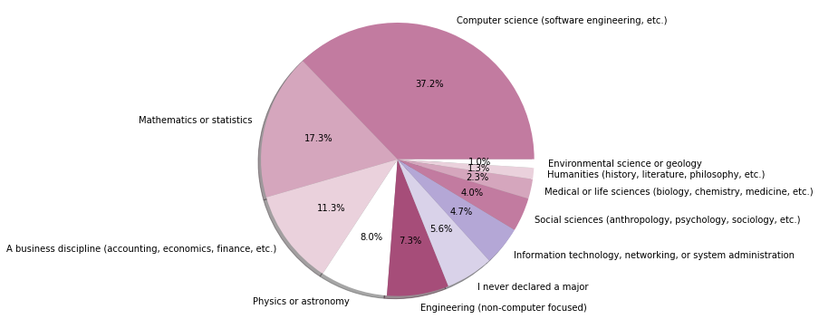

```python
# linia wskazuje że będzie to wykres złożony - wymiary: 6:6
fig1, ax1 = plt.subplots(figsize=(10,5))

colors = ['#c27ba0','#d5a6bd','#ead1dc','#ffffff','#a64d79','#d9d2e9','#b4a7d6']

ax1.pie(sizes, colors=colors, labels=labels, autopct='%1.1f%%', shadow=True, startangle=0)
# Equal aspect ratio ensures that pie is drawn as a circle

ax1.axis('equal')
plt.tight_layout()
plt.show()
```

### Changing size and color of the all fonts

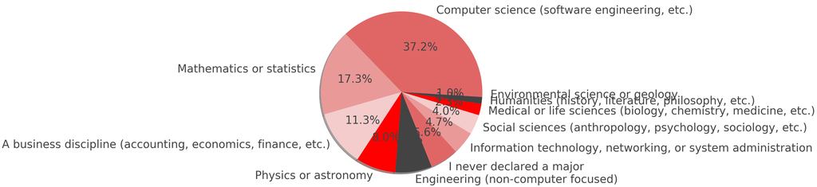

```python
# linia wskazuje że będzie to wykres złożony - wymiary: 6:6
fig1, ax1 = plt.subplots(figsize=(18,12))

colors = ['#e06666','#ea9999','#f4cccc','#ff0000','#434343']

ax1.pie(sizes, colors=colors, labels=labels, autopct='%1.1f%%', shadow=True, startangle=0, textprops={'fontsize': 40, 'color':'#434343'})
# Equal aspect ratio ensures that pie is drawn as a circle

ax1.axis('equal')
plt.tight_layout()
plt.show()
```

### Changing size and color of the separate fonts

```
for text in texts:
    text.set_color('darkred')
for autotext in autotexts:
    autotext.set_color('grey')
```

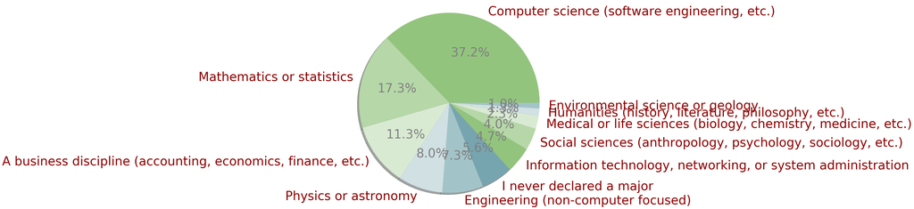

```python
fig1, ax1 = plt.subplots(figsize=(15,12))

colors = ['#93c47d','#b6d7a8','#d9ead3','#d0e0e3','#a2c4c9','#76a5af']

patches, texts, autotexts = ax1.pie(sizes, colors=colors, labels=labels, autopct='%1.1f%%',textprops={'fontsize': 40}, shadow=True, startangle=0)

for text in texts:
    text.set_color('darkred')
for autotext in autotexts:
    autotext.set_color('grey')

ax1.axis('equal')
plt.tight_layout()
plt.show()
```

### Changing size and color for the chosen categories

https://medium.com/@kvnamipara/a-better-visualisation-of-pie-charts-by-matplotlib-935b7667d77f

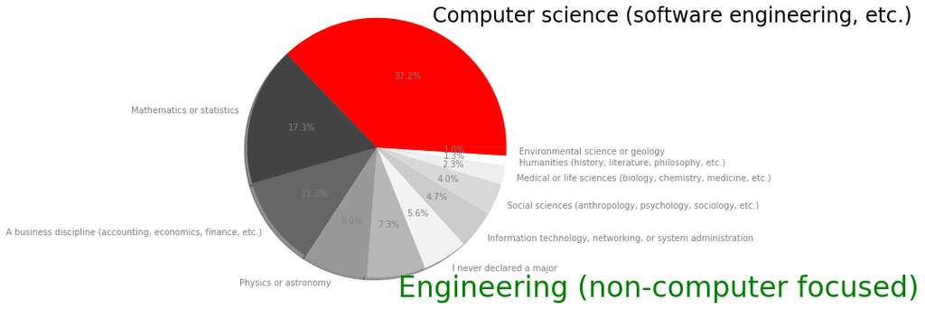

```python
fig1, ax1 = plt.subplots(figsize=(6,6))

colors = ['#ff0000','#434343','#666666','#999999','#b7b7b7','#f3f3f3','#cccccc','#d9d9d9','#efefef','#ffffff']

patches, texts, autotexts = ax1.pie(sizes, colors=colors, labels=labels, autopct='%1.1f%%', shadow=True, startangle=0)


for text in texts:
    text.set_color('grey')
for autotext in autotexts:
    autotext.set_color('grey')


texts[0].set_fontsize(24)
texts[0].set_color('black')
texts[4].set_fontsize(33)
texts[4].set_color('green')

ax1.axis('equal')
plt.tight_layout()
plt.show()
```

### Making a bagel

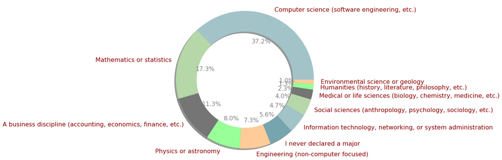

```python
fig1, ax1 = plt.subplots(figsize=(18,6))

colors = ['#a2c4c9','#b6d7a8','#747574','#99ff99','#ffcc99','#76a5af']

patches, texts, autotexts = ax1.pie(sizes, colors=colors, labels=labels, autopct='%1.1f%%', shadow=True, startangle=0, textprops={'fontsize': 16}, wedgeprops=dict(width=.3))
# Equal aspect ratio ensures that pie is drawn as a circle

for text in texts:
    text.set_color('darkred')
for autotext in autotexts:
    autotext.set_color('grey')

ax1.axis('equal')
plt.tight_layout()

plt.show()
```

### Making the better bangle

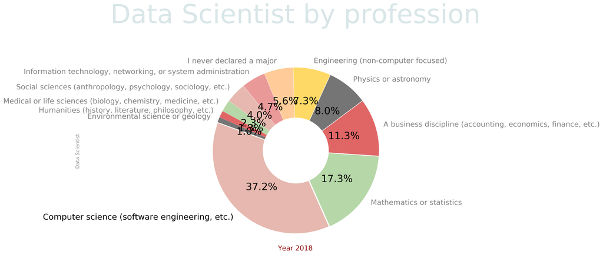

```python
fig1, ax1 = plt.subplots(figsize=(18,8), dpi= 280, facecolor='white', edgecolor='yellow')

colors = ['#e6b8af','#b6d7a8','#e06666','#747574','#ffd966','#ffcc99','#ea9999']
#explode = ( 0.01, 0.01, 0.01, 0.01, 0.01, 0.01, 0.01, 0.01, 0.01, 0.01, 0.01) musi być ta sama liczba co zmiennych na wykresie
patches, texts, autotexts = ax1.pie(sizes, colors=colors, labels=labels, autopct='%1.1f%%',explode=explode, shadow=False, startangle=160, textprops={'fontsize': 16})


for text in texts:
    text.set_color('grey')
for autotext in autotexts:
    autotext.set_color('black')
    autotext.set_fontsize(22)

texts[0].set_fontsize(18)
texts[0].set_color('black')

#draw circle
centre_circle = plt.Circle((0,0),0.40,fc='white')
fig = plt.gcf()
fig.gca().add_artist(centre_circle)


ax1.set_xlabel('Year 2018',  fontsize=15, color='darkred', alpha=1)
ax1.set_ylabel('Data Scientist', fontsize=11,  color='grey', alpha=0.8)
ax1.set_title('Data Scientist by profession',  fontdict={'fontsize': 58, 'fontweight': 'medium', 'color':'#d0e0e3','alpha':0.8, 'y':1.18} )
ax1.set_facecolor('#d8dcd6')


ax1.axis('equal')
plt.tight_layout()

plt.show()
#fig.savefig('test.jpg')
```

### We enter the gender variable

```python
PL.columns
```

```
Index(['Duration (in seconds)', 'Gender', 'Age', 'Country', 'Education',
       'Major_undergraduate', 'Recent_role', 'Industry', 'Years_of_experience',
       'compensation$USD'],
      dtype='object')
```

```python
Z6 = PL.pivot_table(index=['Major_undergraduate','Gender'], values='Age',aggfunc='count').sort_values('Age', ascending=False)
Z6.head(10)
```

| Major_undergraduate | Gender | Age |
| --- | --- | --- |
| Computer science (software engineering, etc.) | Male | 96 |
| Mathematics or statistics | Male | 39 |
| A business discipline (accounting, economics, finance, etc.) | Male | 24 |
| Physics or astronomy | Male | 20 |
| Engineering (non-computer focused) | Male | 18 |
| Computer science (software engineering, etc.) | Female | 15 |
| I never declared a major | Male | 15 |
| Mathematics or statistics | Female | 12 |
| Information technology, networking, or system administration | Male | 11 |
| A business discipline (accounting, economics, finance, etc.) | Female | 9 |

https://medium.com/@kvnamipara/a-better-visualisation-of-pie-charts-by-matplotlib-935b7667d77f

To prepare perfect pie plot first I will need to pull vectors of data from the pivot table.

```python
PLG=Z6.reset_index()
PLG.head(2)
```

|  | Major_undergraduate | Gender | Age |
| --- | --- | --- | --- |
| 0 | Computer science (software engineering, etc.) | Male | 96 |
| 1 | Mathematics or statistics | Male | 39 |

```python
PLG.reset_index()
labels_gender = PLG['Gender'].to_list()
sizes_gender = PLG['Age'].to_list()
```

### The double bangle

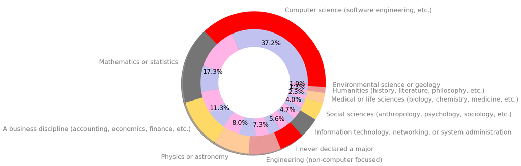

```python
import matplotlib.pyplot as plt


colors_gender = ['#c2c2f0','#ffb3e6']


fig1, ax1 = plt.subplots(figsize=(18,6))

colors = ['#ff0000','#747574','#ffd966','#ffcc99','#ea9999']

patches, texts, autotexts = ax1.pie(sizes, colors=colors, labels=labels, autopct='%1.1f%%', shadow=True, startangle=0, textprops={'fontsize': 16})

plt.pie(sizes_gender,colors=colors_gender,radius=0.75,startangle=0)
centre_circle = plt.Circle((0,0),0.5,color='black', fc='white',linewidth=0)
fig = plt.gcf()
fig.gca().add_artist(centre_circle)




for text in texts:
    text.set_color('grey')
for autotext in autotexts:
    autotext.set_color('black')


#draw circle
centre_circle = plt.Circle((0,0),0.50,fc='white')
fig = plt.gcf()
fig.gca().add_artist(centre_circle)


ax1.axis('equal')
plt.tight_layout()

plt.show()
```

The double bangle is: "one bridge too far". This plot is beautiful but bangles are not correlated each other. To achieve adequate connection vectors should be come from one pivot tables. At the moment I have no idea how to do it (this groupby, query, pivot ....).

# Trigger to create Pie Plot

#### Components to create perfect pie plot: labels, sizes, colors

To prepare perfect pie plot first I will need to pull vectors of data from the pivot table.

```python
PPL=Z5.reset_index()
PPL.head(5)
PPL.reset_index()

labels = PPL['Major_undergraduate'].to_list()
sizes = PPL['Age'].to_list()

colors = ['#a2c4c9','#76a5af','#c9daf8','#a4c2f4', '#cfe2f3']
```

```python
def PPieP(sizes,labels,colors,title):
    fig1, ax1 = plt.subplots(figsize=(18,8), dpi= 280, facecolor='white', edgecolor='yellow')

    patches, texts, autotexts = ax1.pie(sizes, colors=colors, labels=labels, autopct='%1.1f%%', shadow=False, startangle=160, textprops={'fontsize': 16})


    for text in texts:
        text.set_color('grey')
    for autotext in autotexts:
        autotext.set_color('black')
        autotext.set_fontsize(22)

    texts[0].set_fontsize(18)
    texts[0].set_color('darkred')

    #draw circle
    centre_circle = plt.Circle((0,0),0.40,fc='white')
    fig = plt.gcf()
    fig.gca().add_artist(centre_circle)


    ax1.set_xlabel('Year 2018',  fontsize=15, color='darkred', alpha=1)
    ax1.set_ylabel('Data Scientist', fontsize=11,  color='grey', alpha=0.8)
    ax1.set_title(title,  fontdict={'fontsize': 58, 'fontweight': 'medium', 'color':'#d0e0e3','alpha':0.8, 'y':1.18} )
    ## 'fontweight': 'bold', 'light', 'medium'

    ax1.set_facecolor('#d8dcd6')


    ax1.axis('equal')
    plt.tight_layout()

    plt.show()
```

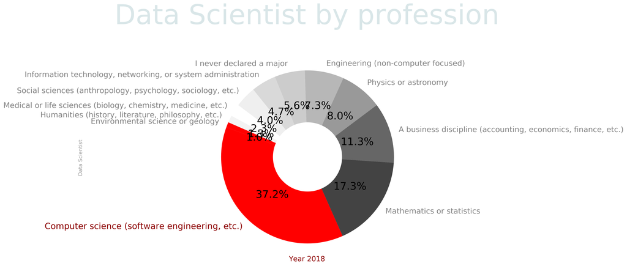

```python
# Variables to the trigger:

labels = PPL['Major_undergraduate'].to_list()
sizes = PPL['Age'].to_list()
#colors = ['#a2c4c9','#76a5af','#c9daf8','#a4c2f4', '#cfe2f3']
#colors = ['#ff0000','#747574','#ffd966','#ffcc99','#ea9999']
#colors = ['#e6b8af','#b6d7a8','#e06666','#747574','#ffd966','#ffcc99','#ea9999']
#colors = ['#93c47d','#b6d7a8','#d9ead3','#d0e0e3','#a2c4c9','#76a5af']
#colors = ['#c27ba0','#d5a6bd','#ead1dc','#ffffff','#a64d79','#d9d2e9','#b4a7d6']
#colors = ['#cfe2f3','#9fc5e8','#6fa8dc']
#colors = ['#d9ead3','#b6d7a8','#93c47d','#6aa84f']
#=> niemieckie czasopismo
colors = ['#ff0000','#434343','#666666','#999999','#b7b7b7','#cccccc','#d9d9d9','#efefef','#ffffff','#f3f3f3']


title = 'Data Scientist by profession'


# Trigger:

PPieP(sizes,labels,colors, title)
```

Good advice in making presentation is to prepare plots using one standard. As says man who built my house: messy but equally